# Warren - Module 1 + 2

## Charts

```r
#data
sf_con_price <- warren_bha %>%
  filter(restype == "R1F" | restype == "CON") %>%
  mutate(
    price_bin = case_when(price_adj < 200000 ~ "Less than $200k",
                          price_adj >= 200000 & price_adj < 400000 ~ "$200k to <$400k",
                          price_adj >= 400000 & price_adj < 600000 ~ "$400k to <$600k",
                          price_adj >= 600000 & price_adj < 800000 ~ "$600k to <$800k",
                          price_adj >= 800000 ~ "$800k+"
                          )
  ) %>%
  select(year, price_bin, investor_type_purchase)
```

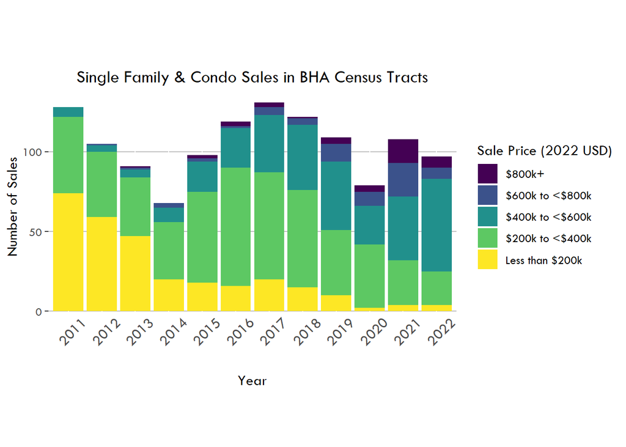

```r
#chart
price_bin_years <- ggplot(data = sf_con_price%>%filter(year>2010),
                     aes(x = as.factor(year),
                         fill = factor(price_bin, levels = c("$800k+", "$600k to <$800k",
                                                             "$400k to <$600k", "$200k to <$400k", "Less than $200k"),)
                     )) +
  geom_bar() +
  scale_fill_viridis(discrete = TRUE) +
  labs(title = "Single Family & Condo Sales in BHA Census Tracts") +
  xlab("Year") +
  ylab("Number of Sales") +
  guides(fill=guide_legend(title="Sale Price (2022 USD)")) +
  theme(text = element_text(size = 12, family = "TwCenMT"),
        plot.title = element_text(hjust = 0.5, family = "TwCenMT"),
        panel.background = element_rect("white"),
        panel.grid.major.y = element_line("grey"),
        axis.text.x = element_text(size = 12, vjust = 1, angle = 45),
        axis.ticks.x = element_blank(),
        axis.title.x = element_text(vjust = -3),
        legend.position = "right",
        aspect.ratio = 9/16
        )

price_bin_years
```

```r
# ggsave( price_bin_years, filename = "Visualizations/sf_con_bha_tract_sales.png", width = 10, height = 8)
```

Home sale transactions - including foreclosures annual price line chart median price (SF+Condo) for region, Boston, and BHA corridor - BHA corridor aggregated tracts

```r
#WITH FORECLOSURES
bha_med <- warren_bha %>%
  filter(restype == "R1F" | restype == "CON") %>%
  select(year, price_adj) %>%
  group_by(year) %>%
  summarise(med_price = median(price_adj)) %>%
  mutate(geog = "Blue Hill Ave (BHA)")

bos_med <- warren_bos %>%
  filter(restype == "R1F" | restype == "CON") %>%
  select(year, price_adj) %>%
  group_by(year) %>%
  summarise(med_price = median(price_adj)) %>%
  mutate(geog = "City of Boston (including BHA)")

ma_med <- warren_mapc %>%
  filter(restype == "R1F" | restype == "CON") %>%
  select(year, price_adj) %>%
  group_by(year) %>%
  summarise(med_price = median(price_adj)) %>%
  mutate(geog = "Metro Boston")

median_sale <- rbind(bha_med, bos_med, ma_med)
```

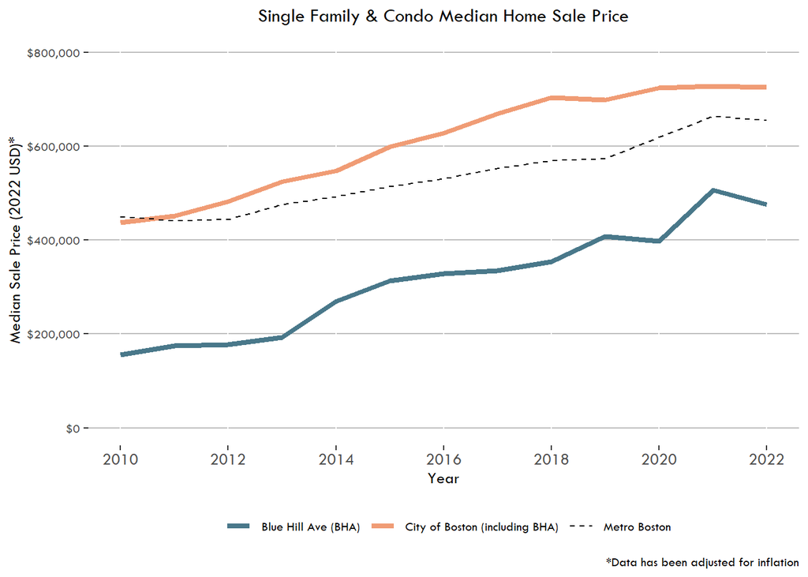

```r
########### WITH FORECLOSURES
windowsFonts(TwCenMT = windowsFont("Tw Cen MT"))
palette <- c("#49788A", "#F09C75", "black") #, "#F24B4B"

median_sale_price <- ggplot(data = filter(median_sale, year >= 2010 & geog != 'Metro Boston'),
                     aes(x = year,
                         y = med_price,
                         group = geog,
                         color = geog
                     )) +
  geom_line(lwd=1.5) +
  geom_line(data = filter(median_sale, year >= 2010 & geog == "Metro Boston"), linetype = 2) +
  scale_color_manual(values = palette) +
  labs(title = "Single Family & Condo Median Home Sale Price") +
  guides(color=guide_legend(title="")) +
  xlab("Year") +
  ylab("Median Sale Price (2022 USD)*") +
  scale_x_continuous(breaks = scales::pretty_breaks()) +
  scale_y_continuous(limits = c(2000, 800000),
                     labels=scales::dollar_format()) +
  theme(text = element_text(size = 10, family = "TwCenMT"),
        plot.title = element_text(size = 12, hjust = 0.5, family = "TwCenMT"),
        axis.text.x = element_text(size = 10),
        panel.background = element_rect("white"),
        panel.grid.major.y = element_line("grey",),
        legend.key=element_rect(fill="white"),
        legend.position = "bottom",
  ) +
  labs(caption = "*Data has been adjusted for inflation")

median_sale_price
```

```r
# ggsave(median_sale_price, filename = "Visualizations/median_sales.png", width = 10, height = 8)
```

Home sale transactions - excluding foreclosures annual price line chart median price (SF+Condo) for region, Boston, and BHA corridor - BHA corridor aggregated tracts

```r
#data
#WITHOUT FORECLOSURES
bha_med <- warren_bha %>%
  filter((restype == "R1F" | restype == "CON") & deedtype != "FD") %>%
  select(year, price_adj) %>%
  group_by(year) %>%
  summarise(med_price = median(price_adj)) %>%
  mutate(geog = "Blue Hill Ave (BHA)")

bos_med <- warren_bos %>%
  filter((restype == "R1F" | restype == "CON") & deedtype != "FD") %>%
  select(year, price_adj) %>%
  group_by(year) %>%
  summarise(med_price = median(price_adj)) %>%
  mutate(geog = "City of Boston (including BHA)")

ma_med <- warren_mapc %>%
  filter((restype == "R1F" | restype == "CON") & deedtype != "FD") %>%
  select(year, price_adj) %>%
  group_by(year) %>%
  summarise(med_price = median(price_adj)) %>%
  mutate(geog = "Metro Boston")

median_sale_nf <- rbind(bha_med, bos_med, ma_med)
```

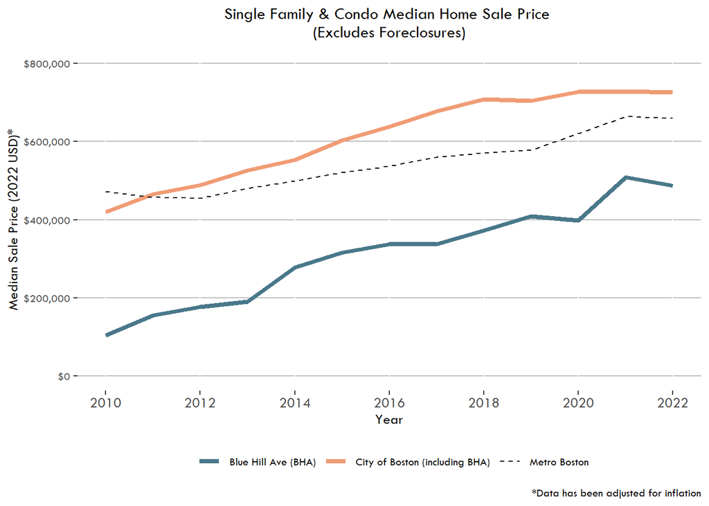

```r
#chart
########### WITHOUT FORECLOSURES
windowsFonts(TwCenMT = windowsFont("Tw Cen MT"))
palette <- c("#49788A", "#F09C75", "black") #, "#F24B4B"

median_sale_price <- ggplot(data = filter(median_sale_nf, year >= 2010 & geog != 'Metro Boston'),
                     aes(x = year,
                         y = med_price,
                         group = geog,
                         color = geog
                     )) +
  geom_line(lwd=1.5) +
  geom_line(data = filter(median_sale_nf, year >= 2010 & geog == "Metro Boston"),
            linetype = 2) +
  scale_color_manual(values = palette) +
  labs(title = "Single Family & Condo Median Home Sale Price \n(Excludes Foreclosures)") +
  guides(color=guide_legend(title="")) +
  xlab("Year") +
  ylab("Median Sale Price (2022 USD)*") +
  scale_x_continuous(breaks = scales::pretty_breaks()) +
  scale_y_continuous(limits = c(2000, 800000),
                     labels=scales::dollar_format()) +
  #guides(fill=guide_legend(title="Sale Price ($2022 USD)")) +
  theme(text = element_text(size = 10, family = "TwCenMT"),
        plot.title = element_text(size = 12, hjust = 0.5, family = "TwCenMT"),
        axis.text.x = element_text(size = 10),
        panel.background = element_rect("white"),
        panel.grid.major.y = element_line("grey",),
        legend.key=element_rect(fill="white"),
        legend.position = "bottom",
  ) +
  labs(caption = "*Data has been adjusted for inflation")

median_sale_price
```

Home sales in the BHA corridor by investor status and size (includes non-investors)

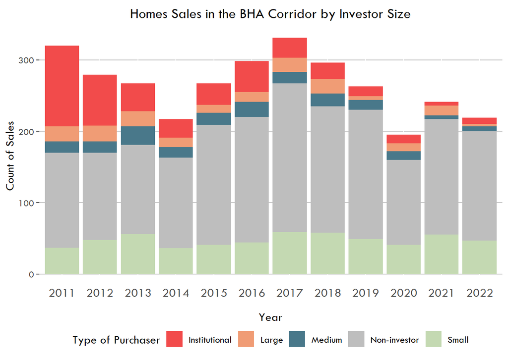

```r
investor <- ggplot(data = (warren_bha%>%filter(year>2010)),
                     aes(x = as.factor(year),
                         fill = factor(investor_type_purchase))) +
  geom_bar() +
  scale_fill_manual(values = c("#F24B4B", "#F09C75","#49788A","grey", "#C4D9B2") ) +
  xlab("Year") +
  ylab("Count of Sales") +
  labs(title = "Homes Sales in the BHA Corridor by Investor Size") +
  guides(fill=guide_legend(title="Type of Purchaser")) +
  theme(text = element_text(size = 12, family = "TwCenMT"),
        plot.title = element_text(hjust = 0.5, family = "TwCenMT"),
        panel.background = element_rect("white"),
        panel.grid.major.y = element_line("grey"),
        axis.text.x = element_text(size = 12, vjust = 2),
        axis.ticks.x = element_blank(),
        axis.title.x = element_text(vjust = -3),
        legend.position = "bottom",
        aspect.ratio = 9/16)

investor
```

Single family and condo sales in the BHA corridor by investor status, size, and sale price

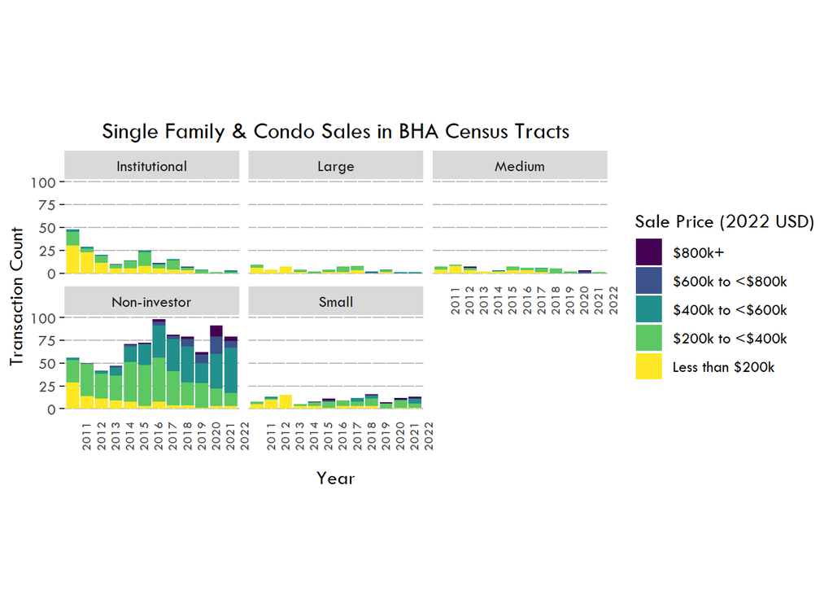

```r
price_bin_years <- ggplot(data = sf_con_price%>%filter(year>2010),
                     aes(x = as.factor(year),
                         fill = factor(price_bin, levels = c("$800k+", "$600k to <$800k",
                                                             "$400k to <$600k", "$200k to <$400k", "Less than $200k"),)
                     )) +
  geom_bar() +
  scale_fill_viridis(discrete = TRUE) +
  labs(title = "Single Family & Condo Sales in BHA Census Tracts"
  ) +
  xlab("Year") +
  ylab("Transaction Count") +
  guides(fill=guide_legend(title="Sale Price (2022 USD)")) +
  theme(text = element_text(size = 12, family = "TwCenMT"),
        plot.title = element_text(hjust = 0.5, family = "TwCenMT"),
        panel.background = element_rect("white"),
        panel.grid.major.y = element_line("grey"),
        axis.text.x = element_text(size = 8, vjust = 2, angle = 90),
        axis.ticks.x = element_blank(),
        axis.title.x = element_text(vjust = -3),
        legend.position = "right",
        aspect.ratio = 9/16) +
  facet_wrap(~investor_type_purchase)

price_bin_years
```

```r
#ggsave( price_bin_years, filename = "Visualizations/sf_con_bha_tract_sales.png", width = 10, height = 8)
```

## MODULE 2: Charts

Investor purchases as share of home purchases - map by tract

```r
inv_purchases <- warren_mapc %>%
  filter(year >= 2010 & year <= 2018 & (restype == "R1F" | restype == "R2F" | restype == "R3F" | restype == "CON")) %>%
  group_by(ct20_id) %>%
  mutate(ct_trans = n()) %>%
  group_by(ct20_id, investor_type_purchase) %>%
  mutate(inv_count = ifelse(investor_type_purchase != 'Non-investor',  n(), 0),
         ct20_id = as.double(ct20_id)) %>%
  ungroup() %>%
  select(ct20_id, inv_count, ct_trans) %>%
  distinct() %>%
  group_by(ct20_id) %>%
  mutate(inv_count = sum(inv_count),
         inv_p = 100*(inv_count/ct_trans)) %>%
  distinct()

inv_purchases %>% summary() # Median ct in MAPC region - 20.4% inv purchases
```

```
##     ct20_id              inv_count         ct_trans          inv_p
##  Min.   :25009201100   Min.   :  0.00   Min.   :   1.0   Min.   :  0.00
##  1st Qu.:25017342202   1st Qu.: 62.00   1st Qu.: 287.0   1st Qu.: 16.67
##  Median :25021401150   Median : 95.00   Median : 456.0   Median : 20.41
##  Mean   :25019589542   Mean   : 99.01   Mean   : 474.3   Mean   : 22.39
##  3rd Qu.:25025010403   3rd Qu.:130.00   3rd Qu.: 657.0   3rd Qu.: 25.59
##  Max.   :25027745100   Max.   :314.00   Max.   :1474.0   Max.   :100.00
##  NA's   :1
```

```r
#write.csv(inv_purchases, "Data/Tabular/inv_purchases_tracts.csv")
```

Investor purchases as a share of SF, condo, 2+3 family home purchases (combined)

```r
#data
bha_inv <- warren_bha %>%
  filter(year >= 2010 & year <= 2018 & (restype == "R1F" | restype == "R2F" | restype == "R3F" | restype == "CON")) %>%
  group_by(year) %>%
  mutate(annual_transactions = n()) %>%
  filter(investor_type_purchase != 'Non-investor') %>%
  mutate(inv_count = n(),
         inv_p = inv_count/annual_transactions,
         geog = "Blue Hill Ave (BHA)") %>%
  select(year, inv_count, annual_transactions, inv_p, geog) %>%
  distinct()

bos_inv <- warren_bos %>%
  filter(year >= 2010 & year <= 2018 & (restype == "R1F" | restype == "R2F" | restype == "R3F" | restype == "CON")) %>%
  group_by(year) %>%
  mutate(annual_transactions = n()) %>%
  filter(investor_type_purchase != 'Non-investor') %>%
  mutate(inv_count = n(),
         inv_p = inv_count/annual_transactions,
         geog = "City of Boston (including BHA)") %>%
  select(year, inv_count, annual_transactions, inv_p, geog) %>%
  distinct()

ma_inv <- warren_mapc %>%
  filter(year >= 2010 & year <= 2018 & (restype == "R1F" | restype == "R2F" | restype == "R3F" | restype == "CON")) %>%
  group_by(year) %>%
  mutate(annual_transactions = n()) %>%
  filter(investor_type_purchase != 'Non-investor') %>%
  mutate(inv_count = n(),
         inv_p = inv_count/annual_transactions,
         geog = "Metro Boston") %>%
  select(year, inv_count, annual_transactions, inv_p, geog) %>%
  distinct()

inv_purchases <- rbind(bha_inv, bos_inv, ma_inv)
```

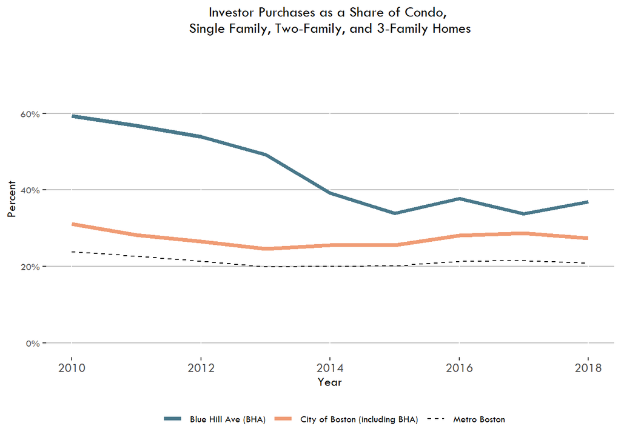

```r
#chart
windowsFonts(TwCenMT = windowsFont("Tw Cen MT"))
palette <- c("#49788A", "#F09C75", "black") #, "#F24B4B"

inv_purchases_line <- ggplot(data = filter(inv_purchases, geog != 'Metro Boston'),
                     aes(x = year,
                         y = inv_p,
                         group = geog,
                         color = geog
                     )) +
  geom_line(lwd=1.5) +
  geom_line(data = filter(inv_purchases, geog == "Metro Boston"),
            linetype = 2) +
  scale_color_manual(values = palette) +
  labs(title = "Investor Purchases as a Share of Condo, \nSingle Family, Two-Family, and 3-Family Homes"
  ) +
  guides(color=guide_legend(title="")) +
  xlab("Year") +
  ylab("Percent") +
  scale_x_continuous(breaks = scales::pretty_breaks()) +
  scale_y_continuous(limits = c(0, 0.75),
    labels=scales::percent_format()) +
  #guides(fill=guide_legend(title="Sale Price ($2022 USD)")) +
  theme(text = element_text(size = 10, family = "TwCenMT"),
        plot.title = element_text(size = 12, hjust = 0.5, family = "TwCenMT"),
        axis.text.x = element_text(size = 10),
        panel.background = element_rect("white"),
        panel.grid.major.y = element_line("grey",),
        legend.key=element_rect(fill="white"),
        legend.position = "bottom",
  )
inv_purchases_line
```

cash sales of SF, condo, 2+3 family homes - map by tract

```r
#data
cash_sales <- warren_mapc %>%
  filter(year >= 2010 & year <= 2022 & (restype == "R1F" | restype == "R2F" | restype == "R3F" | restype == "CON")) %>%
  group_by(ct20_id) %>%
  mutate(ct_trans = n()) %>%
  group_by(ct20_id, cash_sale) %>%
  mutate(cash_count = ifelse(cash_sale == 1, n(), 0)) %>%
  ungroup() %>%
  select(ct20_id, cash_count, ct_trans) %>%
  distinct() %>%
  group_by(ct20_id) %>%
  mutate(cash_count = sum(cash_count),
         cash_p = 100*(cash_count/ct_trans)) %>%
  distinct()

cash_sales %>% summary() # Median ct in MAPC region - 22.34% cash purchases
```

```
##     ct20_id              cash_count     ct_trans          cash_p
##  Min.   :25009201100   Min.   :  0   Min.   :   1.0   Min.   :  0.00
##  1st Qu.:25017342276   1st Qu.: 92   1st Qu.: 412.0   1st Qu.: 18.61
##  Median :25021401652   Median :145   Median : 657.0   Median : 22.34
##  Mean   :25019619653   Mean   :160   Mean   : 683.7   Mean   : 24.68
##  3rd Qu.:25025010431   3rd Qu.:212   3rd Qu.: 964.0   3rd Qu.: 28.54
##  Max.   :25027745100   Max.   :612   Max.   :2203.0   Max.   :100.00
##  NA's   :1
```

```r
#write.csv(cash_sales, "Data/Tabular/cash_sales_tracts.csv")
```

cash sales of SF, condo, 2+3 family homes - chart

```r
#data
bha_cash <- warren_bha %>%
  filter(year >= 2010 & year <= 2022 & (restype == "R1F" | restype == "R2F" | restype == "R3F" | restype == "CON")) %>%
  group_by(year) %>%
  mutate(annual_transactions = n()) %>%
  filter(cash_sale == 1) %>%
  mutate(cash_count = n(),
         cash_p = cash_count/annual_transactions,
         geog = "Blue Hill Ave (BHA)") %>%
  select(year, cash_count, annual_transactions, cash_p, geog) %>%
  distinct()

bos_cash <- warren_bos %>%
  filter(year >= 2010 & year <= 2022 & (restype == "R1F" | restype == "R2F" | restype == "R3F" | restype == "CON")) %>%
  group_by(year) %>%
  mutate(annual_transactions = n()) %>%
  filter(cash_sale == 1) %>%
  mutate(cash_count = n(),
         cash_p = cash_count/annual_transactions,
         geog = "City of Boston (including BHA)") %>%
  select(year, cash_count, annual_transactions, cash_p, geog) %>%
  distinct()

ma_cash <- warren_mapc %>%
  filter(year >= 2010 & year <= 2022 & (restype == "R1F" | restype == "R2F" | restype == "R3F" | restype == "CON")) %>%
  group_by(year) %>%
  mutate(annual_transactions = n()) %>%
  filter(cash_sale == 1) %>%
  mutate(cash_count = n(),
         cash_p = cash_count/annual_transactions,
         geog = "Metro Boston") %>%
  select(year, cash_count, annual_transactions, cash_p, geog) %>%
  distinct()

cash_purchases <- rbind(bha_cash, bos_cash, ma_cash)
```

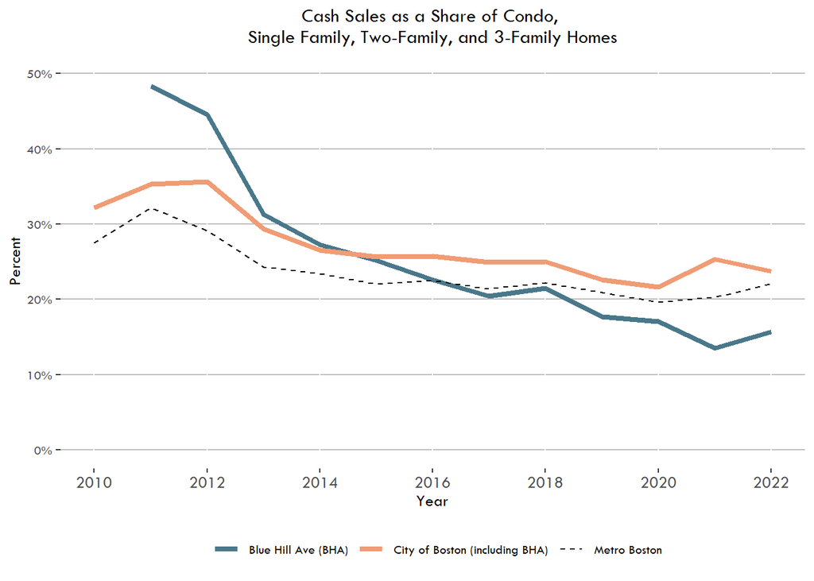

```r
#chart
windowsFonts(TwCenMT = windowsFont("Tw Cen MT"))
palette <- c("#49788A", "#F09C75", "black") #, "#F24B4B"

cash_purchases_line <- ggplot(data = filter(cash_purchases, geog != 'Metro Boston'),
                     aes(x = year,
                         y = cash_p,
                         group = geog,
                         color = geog
                     )) +
  geom_line(lwd=1.5) +
  geom_line(data = filter(cash_purchases, geog == "Metro Boston"),
            linetype = 2) +
  scale_color_manual(values = palette) +
  labs(title = "Cash Sales as a Share of Condo, \nSingle Family, Two-Family, and 3-Family Homes"
  ) +
  guides(color=guide_legend(title="")) +
  xlab("Year") +
  ylab("Percent") +
  scale_x_continuous(breaks = scales::pretty_breaks()) +
  scale_y_continuous(limits = c(0, 0.5),
    labels=scales::percent_format()) +
  #guides(fill=guide_legend(title="Sale Price ($2022 USD)")) +
  theme(text = element_text(size = 10, family = "TwCenMT"),
        plot.title = element_text(size = 12, hjust = 0.5, family = "TwCenMT"),
        axis.text.x = element_text(size = 10),
        panel.background = element_rect("white"),
        panel.grid.major.y = element_line("grey",),
        legend.key=element_rect(fill="white"),
        legend.position = "bottom",
  )
cash_purchases_line
```

Speculation: statistic: buy side flips - percent of SF, condo, 2+3 family homes purchases that were flipped (investor and non-investor) - BHA corridor

```r
#statistic: # of flipped Single Family, Condo, 2 Family, and 3 Family properties from 2010 to 2020 in BHA corrdidor tracts
#start w/BHA tracts only
warren_bha %>%
  filter(
    #buy side flips only
    buy_side_flip == 1 &
    #from 2010-2020
    year >= 2010 & year <= 2020 &
    #in these restypes only
    (restype == "R1F" | restype == "R2F" | restype == "R3F" | restype == "CON")
      ) %>%
  #count() #408 flips
  count(restype) # condos are flipped half as often as R1F, R2F, and R3F
```

```
## # A tibble: 4 × 2
##   restype     n
##   <chr>   <int>
## 1 CON        54
## 2 R1F       110
## 3 R2F       137
## 4 R3F       107
```

```r
  #count(investor_type_purchase) #75% of flips are by investors - 31% by institutional investors
  #count(cash_sale) # ~45% of flips are cash sales on the buy-side
```